**ALY 6000 - Introduction to Analytics**  
**Northeastern University**

Analytics Report for Office Supply Store - 2020

Maheswar Raju Narasaiah  
Date: 29 October, 2022

# 1. Introduction

As digital services have grown in popularity, the office supply store industry has seen consistent revenue growth. Despite the fact that the industry was already declining, the onset of the COVID-19 (coronavirus) pandemic in 2020 is expected to exacerbate this trend. As a result, industry revenue is expected to fall at an annualized rate of 3.8% to $11.5 billion over the next five years, with a 1.2% increase in 2022 alone. It should be noted, however, that the increase in revenue in 2021 and 2022 is primarily a reaction to the large decrease in revenue in 2020 and is not indicative of typical industry trends. In 2020 alone, industry revenue fell 5.1%, owing primarily to poor economic conditions and low consumer purchasing power (Ünal et al.,2018).

In the midst of the coronavirus crisis, working from home is becoming the new normal in almost every country around the world. As traditional offices remain almost empty and most paperwork migrates to digital platforms, demand for core stationery products such as pens and paper has decreased (Manuszak & Moul, 2008). Meanwhile, sales and demand for home offices and standalone desks, headphones, monitors, and similar equipment have shifted.

**The Importance of Analytics in Supplies Chain.**

Every department requires a robust business intelligence strategy for data analytics and business information management to assist teams in making more data-driven decisions and gaining a competitive advantage over other businesses. Because every step can be planned utilizing evidence, insights and business intelligence have the potential to fundamentally alter the way a task is carried out.

Any supply chain leader will agree that managing and constantly improving a global supply chain is difficult. You are tasked with coordinating operations among a large assortment of suppliers, vendors, buyers, carriers, agents, and local and international business partners, all with the common goal of providing a world-class customer experience (Malcata-Rebelo & Pinho, 2010). However, with so many moving parts, the amount of data and information flowing, and the numerous disruptions that constantly put your supply chain to the test, this can be extremely difficult. Naturally, a massive amount of data is generated in this complex system. Industry leaders are quickly recognizing the significance of analytics in their institutions in order to effectively manage and use this data.

According to a Gartner study, approximately 79% of supply chain leaders are working on plans to train their teams on the use of advanced analytics. So, what makes this so critical to the success of your supply chain? And how will you get forward with of this problem and make the most of your supply chain data? This article will go over exactly that.

**Application of Big Data Analytics in Supply Chain Analytics**

Big data in the office furniture industry can include anything from consumer preferences and behavior to buying patterns, places, and other information derived from sales data and online reviews. Companies that use big data see an average 8% increase in profits over those that do not. With the advent of customization, data engines and dashboards can be shaped to meet the business needs of each department, whether it’s job recruitment, social media marketing performance, or managerial accounting (Dalkir & Warren, 2018).

Supply chain analytics has a wide range of benefits for a company’s supply chain operations. When used properly, it enables businesses to convert data into actionable reports, dashboards, and visualizations in order to achieve better results by:

- Improved decision making in a company’s supply chain operations
- Understanding, identifying, and monitoring potential risks
- Facilitating accurate demand forecasting
- Identifying and quantifying delay patterns
- Optimizing inventory balance and avoiding excess/short stock

All of this results in increased agility and resilience of your global supply chain, better control over orders, shipments, inventory and permanently lowered operational costs.

**About the Data Set**

In this report, I have examined sales data of Office Supply Store in 2020, which includes details like order Id, order date, shipping locations, finances, etc.

**Problem identification**

As customers become more sophisticated and better-informed because of new trend of online shopping, the sales process is much less about selling a product and much more about creating a relationship. There has been an accompanying shift from product to service (or solution) selling (“servitisation”) in many business-to-business interactions (Leitner, 1994). The emergence of servitisation has inevitably widened the constituency that is involved in the sales and subsequent delivery processes.

In this report, I am examining the change in the role of business-to-customer sales, its behavior, and specially focusing on areas of profits, loss & shipping cost. Through this I would like to answer following question below:

- How did we perform financially in 2020? and how we can improve that?
- What does our most profitable product mix look like?
- What are the things your customer preferred needs?
- How is our current shipping cost for different regions?
- What else plays a role in the customer’s purchase?

**Methodology/Approach**

This report is structured as follows: first, we are present some descriptive statistics of price, quantity, discount, shipping cost, and profits and see if there are any connection between. Second, we check what is our most frequent price, quantity, discount & shipping cost, check the interaction between sales and other functions of a firm. Third, we compare different categories of segment, market, department & ship mode, and its observations. Fourth, we will discuss some business questions and findings from them. And then, we will try to analyze the co-relation between profit and loss with respect to segment. Finally, we discuss the conclusions of the article and identify managerial implications and future market opportunities.

However, analyzing and optimizing sales process can hardly be done without the help of additional tools. So, I am using RStudio for visual analytics.

# 2. Analysis

In this section, we will perform analysis on various type of variables to gain insight and address our problems

**2.1. Basic descriptive statistics of Price, Quantity, Discount, Shipping Cost, and Profits**

The table below shows thedescriptive statistics of Price, Quantity, Discount, Shipping Cost, and Profits.

Descriptive Statistics of Price, Quantity, Discount, Shipping Cost & Profits

|  | Mean | StDev | Range | Median |
| --- | --- | --- | --- | --- |
| Price | 548.41 | 293.95 | 3406.28 | 500.84 |
| Quantity | 6.61 | 2.53 | 14.00 | 6.00 |
| Discount | 0.12 | 0.10 | 0.30 | 0.11 |
| Shipping Cost | 36.55 | 13.20 | 83.19 | 40.62 |
| Profits | 1066.54 | 901.22 | 8799.68 | 834.35 |

**2.2. Box plots and histograms of Price, Quantity, Discount, and Shipping Cost**

**2.2.1. Box plots and histograms of Price**

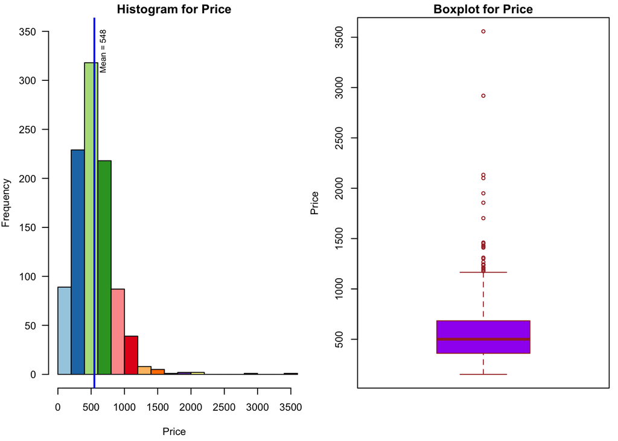

**2.2.2. Box plots and histograms of Quantity**

[figure not shown]

*Observation*

**2.2.3. Box plots and histograms of Discount**

[figure not shown]

*Observation*

**2.2.4. Box plots and histograms of Shipping Cost**

[figure not shown]

*Observation*

**2.3. Compare Different Categories of Segment, Market, Department, and Ship Mode**

**2.3.1. Different Categories of Segment Using Bar Graph**

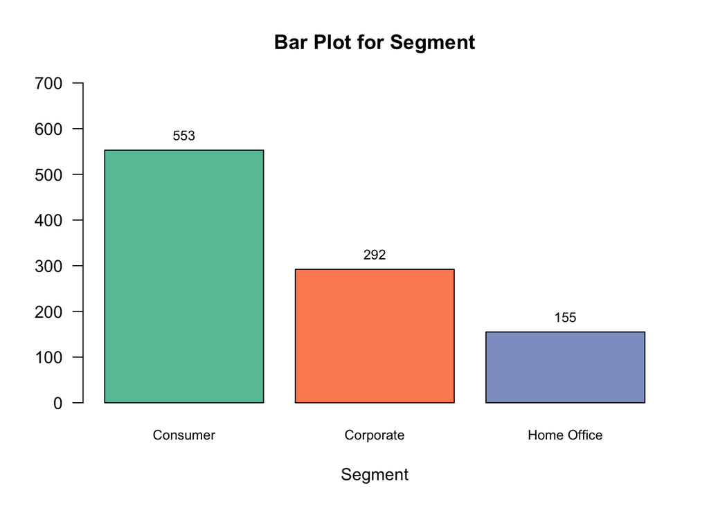

*Observation*

1. The bar graph clearly shows customer buys consumer products which around 55%
2. And least selling product are from Home- Office segment.

**2.3.2. Different Categories of Market Using Bar Graph**

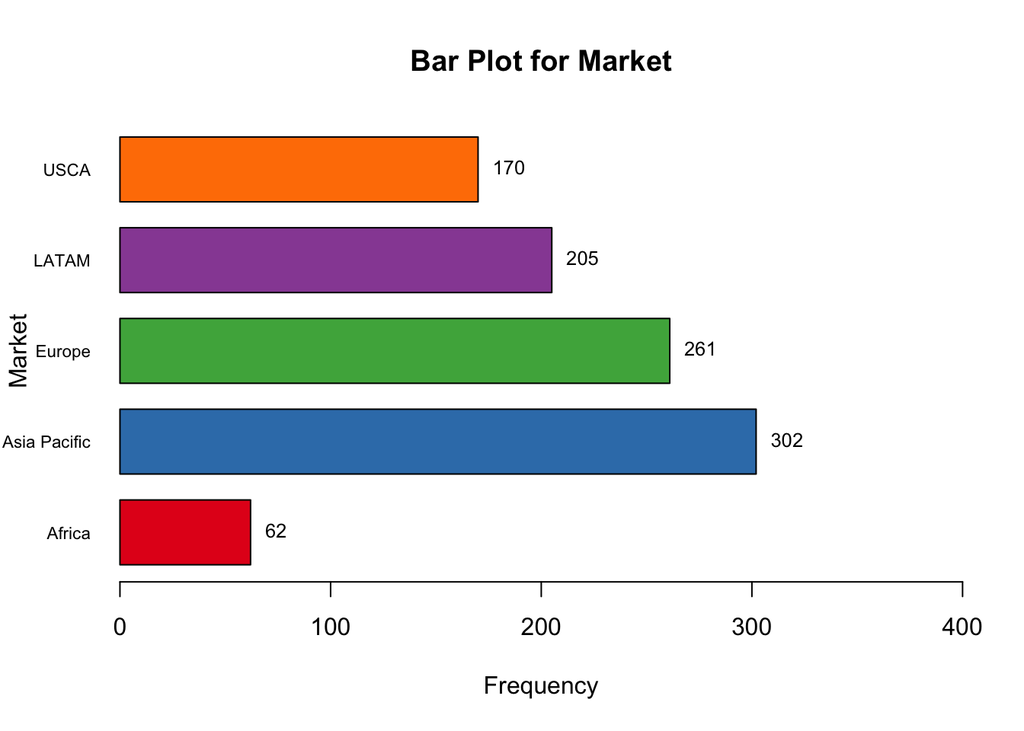

**2.3.3. Different Categories of Department Using Pie Chart**

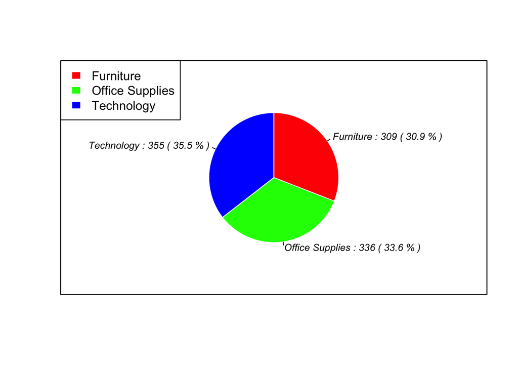

*Observation*

1. Pie Chart shows that we have almost equal share of Department after taking look at the data
2. Technology Department is having very advantage than office supplies due almost only 2 %. 2, We need to focus getting furniture business more as it is having less share amongst three.

**2.3.3. Different Categories of Shipping Mode Using Pie Chart**

[figure not shown]

*Observation*

1. Pie Chart shows that we have standard class mode is mostly how we ship our products to customer, and have almost 55% share
2. Same day mode is least prefferable mode almost only 6.5 %.We need to focus getting shipping products in same day mode more as it is having less share amongst four of them.

**2.4. Business questions, statistics inside sub-categories**

**2.4.1. Total Quantity for Each Shipping Mode Using Dot Chats**

Below dot chart shows the total Quantity with respect to Each Shipping Mode

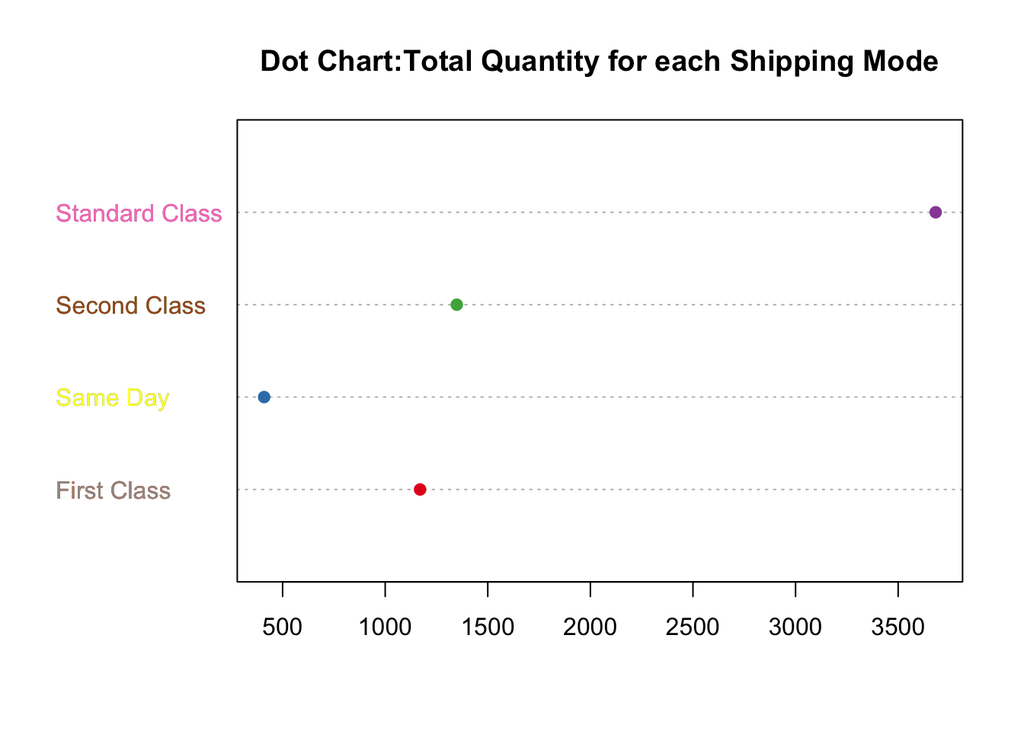

*Observation*

1. Dot Chart shows that most of quantity of products are sold is standard class
2. The second most preferable method of shipping is second class.

**2.4.2. Averarge Shipping Cost For Each Segment Using Bar Graph**

Below bar graph shows the averarge Shipping Cost For Each Segment

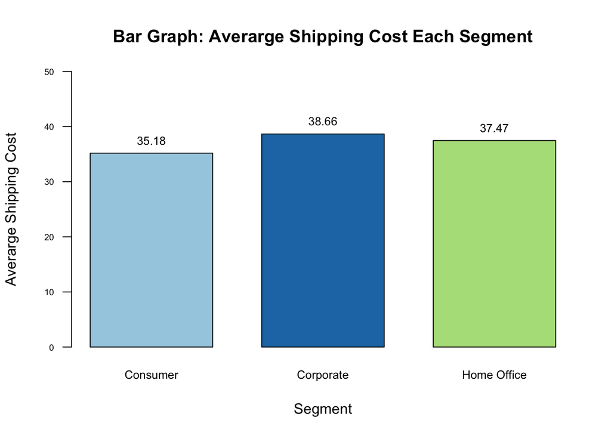

*Observation*

1. The avg. shipping cost for corporate is 38.66 which is greater compared to any other segment, we need to bring down in order to bring down the price
2. The consumer product have less shipping copst at around 35.18

**2.4.3. Median Profits For Each Market Using Scatter Plot**

[figure not shown]

**2.5. Average Shipping Cost Each Segment in Eastern US Region**

Below table and bar plot shows the Average Shipping Cost Each Segment in Eastern US Region.

Average Shipping Cost in each Segment in Eastern US

|  | Avg. Shipping Cost |
| --- | --- |
| Consumer | 12.88 |
| Corporate | 12.81 |
| Home Office | 20.73 |

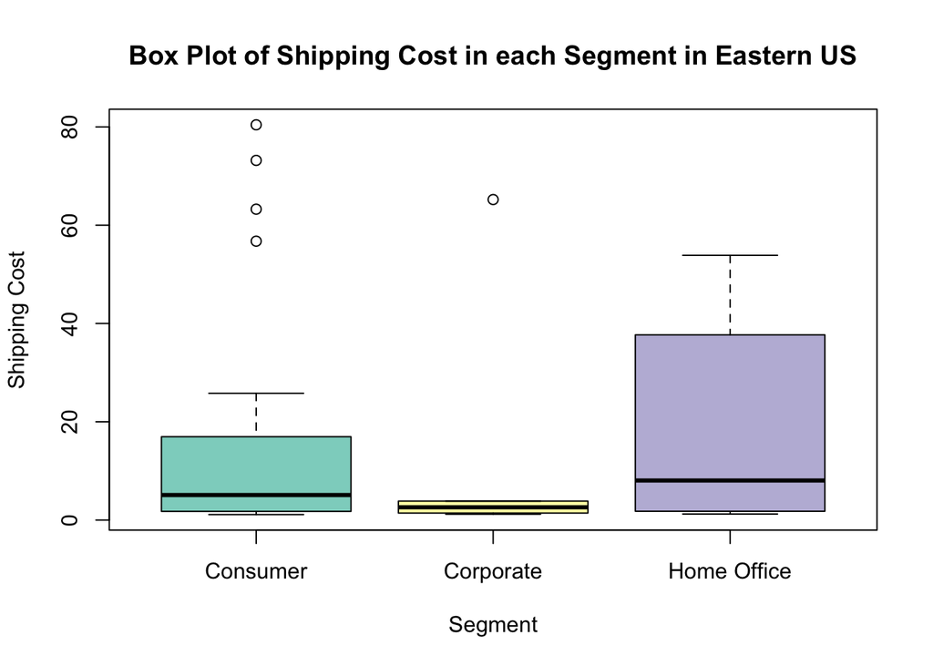

*Observation*

1. The shipping cost for our home-office product is more than 60% of shipping cost of consumer and corporate products.
2. The shipping cost of consumer and corporate products are almost same.

**2.6. Scatter Plot: Profits vs Total Loss for Each Segment**

Below scatter plot is trying to identify is there is co-relation between loss and profits for each segment

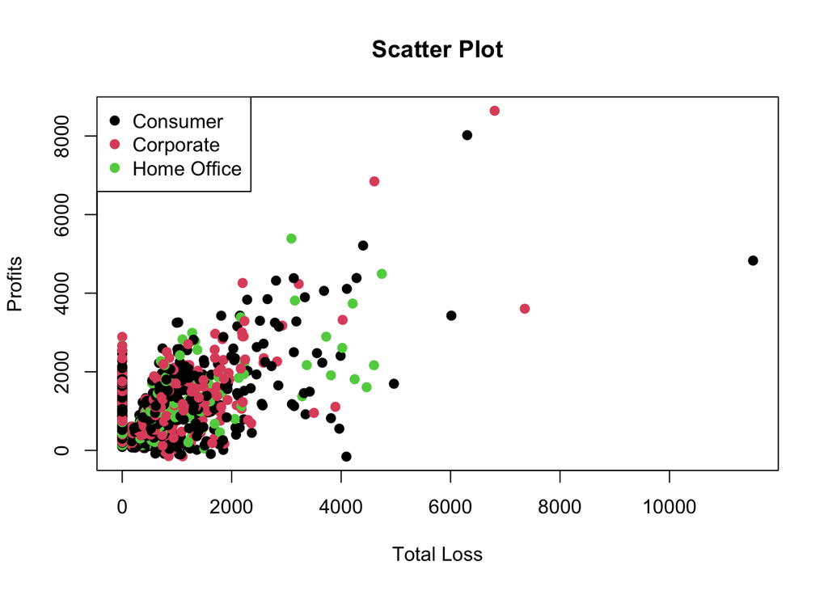

*Observation*

1. The most density of profits and loss for all the segments is below 2000 of profits and 2000 of loss.
2. Scatter plots of profits and loss for each company segment shows that it has have some association with different company segment, so every segment has almost same pattern of sales.

**2.7. Density Plot for Quantity**

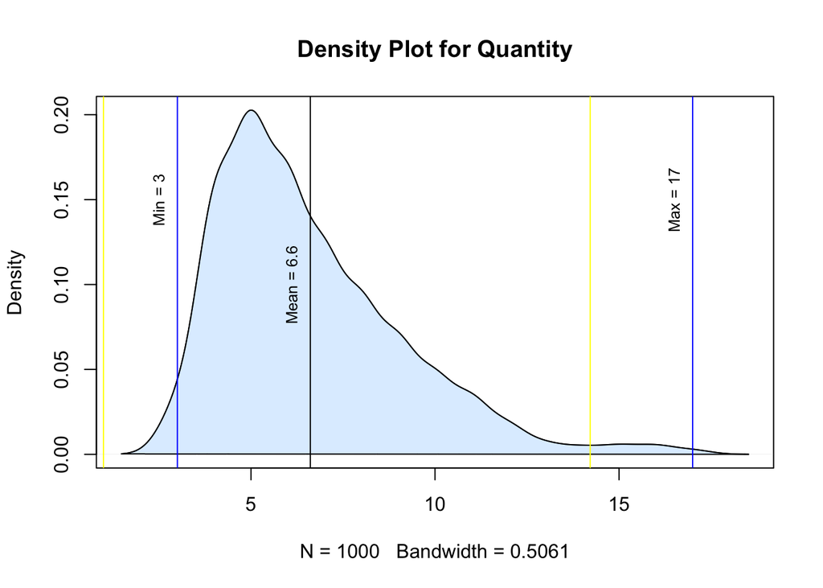

*Observation*

1. Density plot shows that most of sales are made with 5 quantity.
2. Most of the sales takes places at lesser quantities of product, by looking at skewness in scatter plot, and we’ve got a very less sales happening with larger quantities of product.
3. This often what you would expect from when you have things that start at a particular value and really anything associated with money is usually going to end up looking like this.

# 3. Conclusions

**After working on this project, Below are skills that I have learned and improved upon**

1. Business Sense - I have acquired skils to get acquired information to create actionable solutions for businesses. Therefore, they need to understand the nature of the field and specific business they’re working in to come up with solutions that fit best.
2. Attention to Detail - I got accustomed to handling large sets of data, it’s easy to overlook details that might be essential to a project’s outcome. As data analyst we need to analyze mountains of information and use their ability to pay attention to detail to identify and use the most important data sets.
3. Writing Efficient, Maintainable Code - Data scientists work with data, which means they work with systems that process and analyze data. A good data scientist needs to understand how to use programming languages so they can create algorithms or programs to parse data and APIs to collect and prepare data.
4. Debugging Skills: I have improved my debugging skills by trying to find root cause, whenever code was getting struck and wasn’t giving expected results.
5. Critical Thinking - I have developed some crtical thinking as I can look at a problem or scenario and understand how and why the problem exists . The ability to understand the full scope of the problem is the first important step toward developing effective solutions.
6. Tenacity - Not all problems are straightforward, especially in the world of data science. Many challenges have multiple layers, each with its complex nature. Sometimes, this complexity and lack of a simple linear track can cause people to give up. Strong analytical skills mean seeing beyond one issue at a time to develop a more cohesive view of a problem’s complexity.
7. Good Communication - Effective communication is a fine art, and it’s one that successful data scientists refine throughout their careers. Because they often communicate essential information to executives and stakeholders, they must be confident about the data they present and relay it in terms that the layman can understand. You can create the best actionable solutions anyone has ever seen in the history of IT. Still, unless you can relay that information to the people in charge, those solutions won’t go anywhere.
8. Curiosity - Why are things the way they are? What makes things tick? A curious nature and a desire to dig deeper to solve problems are essential tools for a data analyst. Data science involves analyzing and interpreting numbers, and an active curiosity goes a long way in this field.

# 4. References

1. Ünal, E., Urbinati, A., & Chiaroni, D. (2018). Managerial practices for designing circular economy business models: The case of an Italian SME in the office supply industry. Journal of manufacturing technology management
2. Manuszak, M. D., & Moul, C. C. (2008). Prices and endogenous market structure in office supply superstores. The Journal of Industrial Economics, 56(1), 94-112
3. Malcata-Rebelo, E., & Pinho, P. (2010). Evaluation and monitoring of office markets. Environment and Planning B: Planning and Design, 37(2), 305-325
4. Dalkir, S., & Warren-Boulton, F. (2018). Prices, market definition, and the effects of merger: Staples-Office Depot (1997). The Antitrust Revolution: Economics, Competition, and Policy, 7th edn. Oxford University Press, New York (2018).
5. Leitner, H. (1994). Capital markets, the development industry, and urban office market dynamics: rethinking building cycles. Environment and planning a, 26(5), 779-802

# 5. Appendix

An R Markdown file has been attached to this report. The name of the file is Narasaiah_FinalReport(uplicate)